# Geographies of EU dissatisfaction

Does segregation erode the EU project?

09 May 2022

## One Approach to the Topic

After our call a couple of weeks ago, I was really interested to see how attitudes toward European integration are related to presence of EU27-origin migrants in the region. So that’s what I look at in the following analysis. It’s just one possible approach, but I think there is an interesting story emerging here.

## Initial Hypotheses

- The more EU27-origin migrants in your region, the more positive your views toward European integration.
- This relationship erodes as segregation between EU27 migrants and natives increases.

## Data & Variables

Data

- Pooled ESS Rounds 6 and 7 (2012 & 2014) and D4I segregation and population data (2011)

DV

- “euftf”: European unification has already gone too far (0) or should go further (10)

Region-level IVs (in models, all are z-scores)

- Size of EU27-origin migrant population, relative to native population
- Size of non-EU-origin migrant population, relative to rest of population
- Segregation (H index) of EU27-origin migrant population vs. native population
- Segregation (H index) of non-EU-origin migrant population vs. rest of population

Individual-level IVs

- Gender
- Age and age squared
- Years of education and years of education squared
- Occupational class (Oesch 5-level, plus “not working” category)
- Region of birth (native, EU27 country, non-EU country)

Other

- Random intercepts for regions nested in countries and survey round
- Design and population weights

## Linear vs. Ordinal

I initially explored the data using linear lme4 models which I then ran in rstanarm. The models were interesting but didn’t capture the data very well, so I ran the same models as cumulative ordinal models in brms. The improvement was massive:

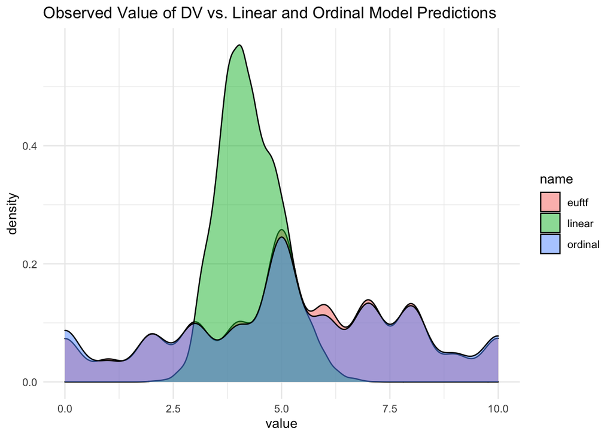

```r
read_rds("~/research/l4_lin_vs_ord.rds") %>% pivot_longer(cols = everything()) %>% ggplot(aes(value,fill=name)) + geom_density(alpha = .5) + labs(color = NULL, title = "Observed Value of DV vs. Linear and Ordinal Model Predictions") + theme_minimal()
```

## Model Progression

Here are a bunch of visualizations of the ordinal models I have run so far. I include the region-level variables progressively. Model 1 has only the two migrant population ratio variables. It suggests that Europeans are happy when integration brings other Europeans to their region, but less happy when non-Europeans arrive.

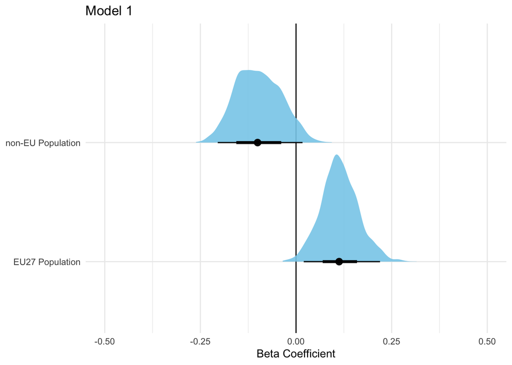

```r
m1 %>%
  spread_draws(b_scalepct_eu_only, b_scalepct_non_eu) %>%
  select(-starts_with(".")) %>%
  rename(`EU27 Population` = b_scalepct_eu_only,
         `non-EU Population` = b_scalepct_non_eu) %>%
  pivot_longer(everything()) %>%
  ggplot(aes(y = name, x = value)) +
  geom_vline(xintercept = 0) +
  stat_halfeye(fill = "skyblue", alpha = .9) +
  coord_cartesian(xlim = c(-.5, .5)) +
  theme_minimal() +
  labs(y = NULL, x = "Beta Coefficient", title = "Model 1")
```

Model 2 includes the segregation variables, without interactions, without much impact on the findings.

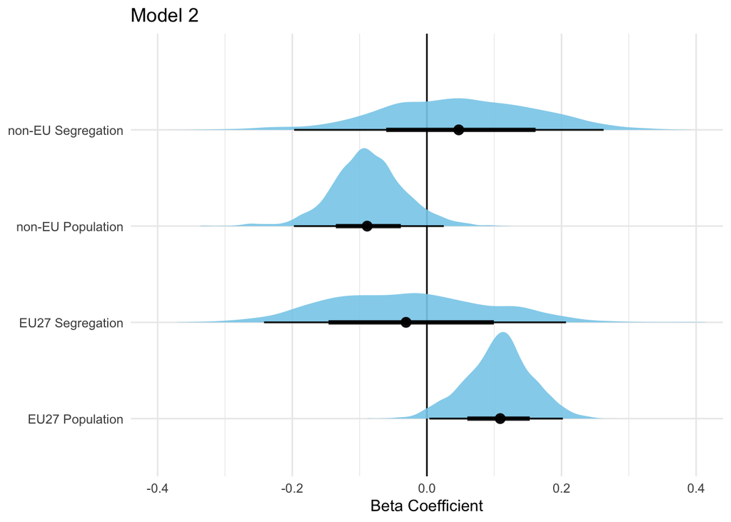

```r
m2 %>%
  spread_draws(b_scalepct_eu_only, b_scaleeu_H, b_scalepct_non_eu, b_scalenon_H) %>%
  select(-starts_with(".")) %>%
  rename(`EU27 Population` = b_scalepct_eu_only,
         `EU27 Segregation` = b_scaleeu_H,
         `non-EU Population` = b_scalepct_non_eu,
         `non-EU Segregation` = b_scalenon_H) %>%
  pivot_longer(everything()) %>%
  ggplot(aes(y = name, x = value)) +
  geom_vline(xintercept = 0) +
  stat_halfeye(fill = "skyblue", alpha = .9) +
  coord_cartesian(xlim = c(-.4, .4)) +
  theme_minimal() +
  labs(y = NULL, x = "Beta Coefficient", title = "Model 2")
```

Model 3 includes interactions between the migrant population variables and their respective segregation variables. Sure enough, it appears likely that the positive impact of a large EU27-origin migrant population is eroded if there is a high level of segregation. There isn’t a ton of confidence in the direction of the interaction (~87%), but by including that variable we see that the relationship between EU27 migrant population and the DV is even clearer.

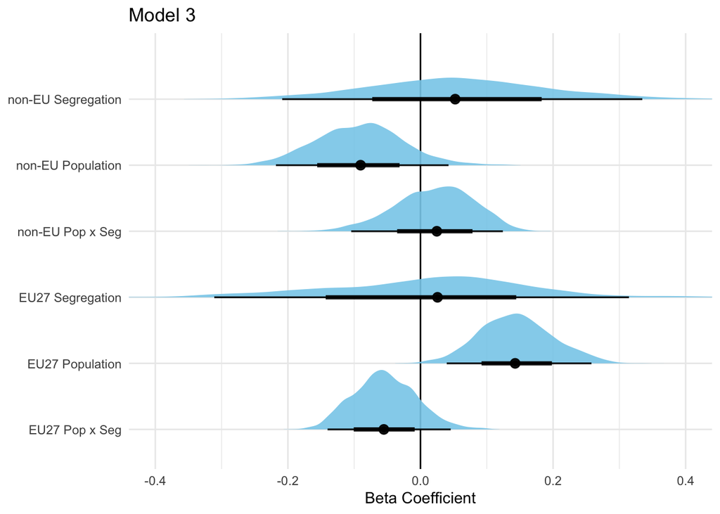

```r
m3 %>%
  spread_draws(b_scalepct_eu_only, b_scaleeu_H, b_scalepct_non_eu, b_scalenon_H,`b_scalepct_eu_only:scaleeu_H`,`b_scalepct_non_eu:scalenon_H`) %>%
  select(-starts_with(".")) %>%
  rename(`EU27 Population` = b_scalepct_eu_only,
         `EU27 Segregation` = b_scaleeu_H,
         `non-EU Population` = b_scalepct_non_eu,
         `non-EU Segregation` = b_scalenon_H,
         `EU27 Pop x Seg` = `b_scalepct_eu_only:scaleeu_H`,
         `non-EU Pop x Seg` = `b_scalepct_non_eu:scalenon_H`) %>%
  pivot_longer(everything()) %>%
  ggplot(aes(y = name, x = value)) +
  geom_vline(xintercept = 0) +
  stat_halfeye(fill = "skyblue", alpha = .9) +
  coord_cartesian(xlim = c(-.4, .4)) +
  theme_minimal() +
  labs(y = NULL, x = "Beta Coefficient", title = "Model 3")
```

## Individual-level Variables

Sticking with Model 3, here is a look at some of the individual-level effects and then a couple of (failed) attempts to find interesting heterogeneous effects.

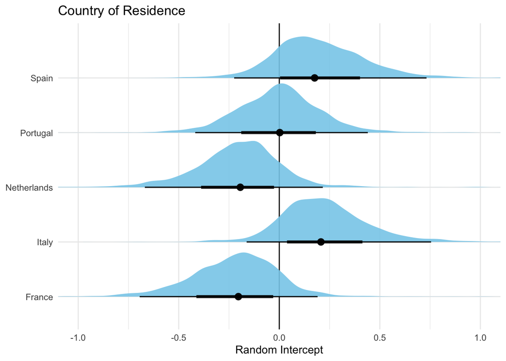

```r
m3 %>%
  spread_draws(`r_cntry[ES,Intercept]`,`r_cntry[FR,Intercept]`,`r_cntry[IT,Intercept]`,`r_cntry[NL,Intercept]`,`r_cntry[PT,Intercept]`) %>%
  rename(Spain = `r_cntry[ES,Intercept]`, France = `r_cntry[FR,Intercept]`,Italy = `r_cntry[IT,Intercept]`,Netherlands = `r_cntry[NL,Intercept]`,Portugal = `r_cntry[PT,Intercept]`) %>%
  select(-starts_with(".")) %>%
  pivot_longer(everything()) %>%
  ggplot(aes(y = name, x = value)) +
  geom_vline(xintercept = 0) +
  stat_halfeye(fill = "skyblue", alpha = .9) +
  coord_cartesian(xlim = c(-1, 1)) +
  theme_minimal() +
  labs(y = NULL, x = "Random Intercept", title = "Country of Residence")
```

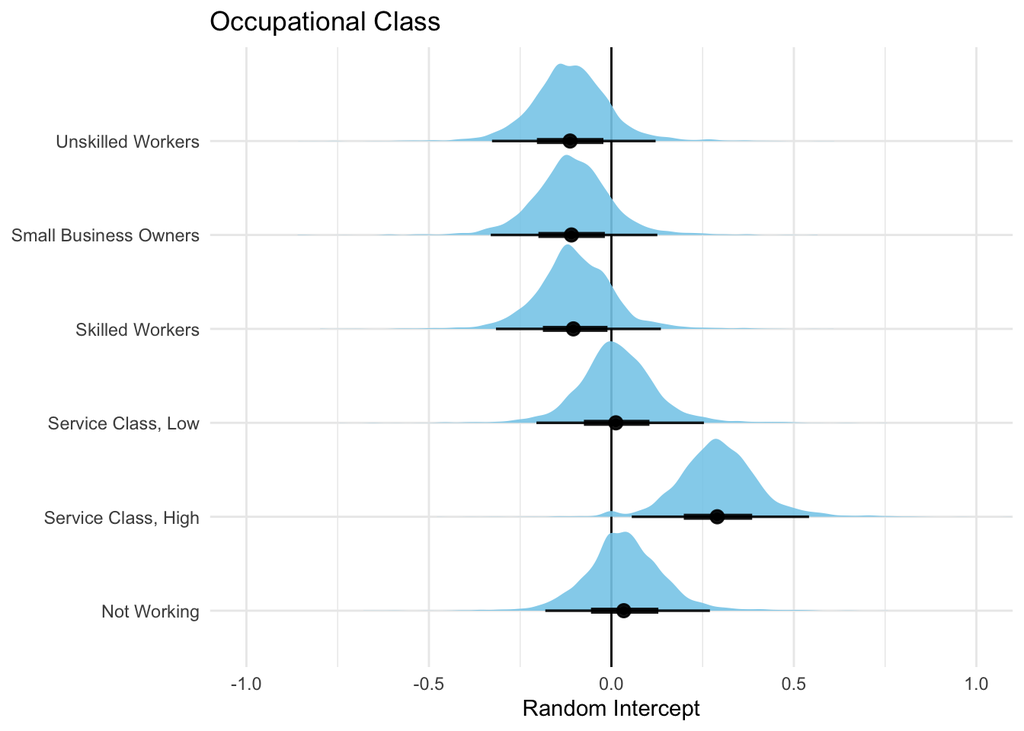

```r
m3 %>%
  spread_draws(`r_class5[1,Intercept]`,`r_class5[2,Intercept]`,`r_class5[3,Intercept]`,`r_class5[4,Intercept]`,`r_class5[5,Intercept]`,`r_class5[not.working,Intercept]`) %>%
  rename(`Service Class, High`=`r_class5[1,Intercept]`,`Service Class, Low`=`r_class5[2,Intercept]`,`Small Business Owners`=`r_class5[3,Intercept]`,`Skilled Workers`=`r_class5[4,Intercept]`,`Unskilled Workers`=`r_class5[5,Intercept]`,`Not Working`=`r_class5[not.working,Intercept]`) %>%
  select(-starts_with(".")) %>%
  pivot_longer(everything()) %>%
  ggplot(aes(y = name, x = value)) +
  geom_vline(xintercept = 0) +
  stat_halfeye(fill = "skyblue", alpha = .9) +
  coord_cartesian(xlim = c(-1, 1)) +
  theme_minimal() +
  labs(y = NULL, x = "Random Intercept", title = "Occupational Class")
```

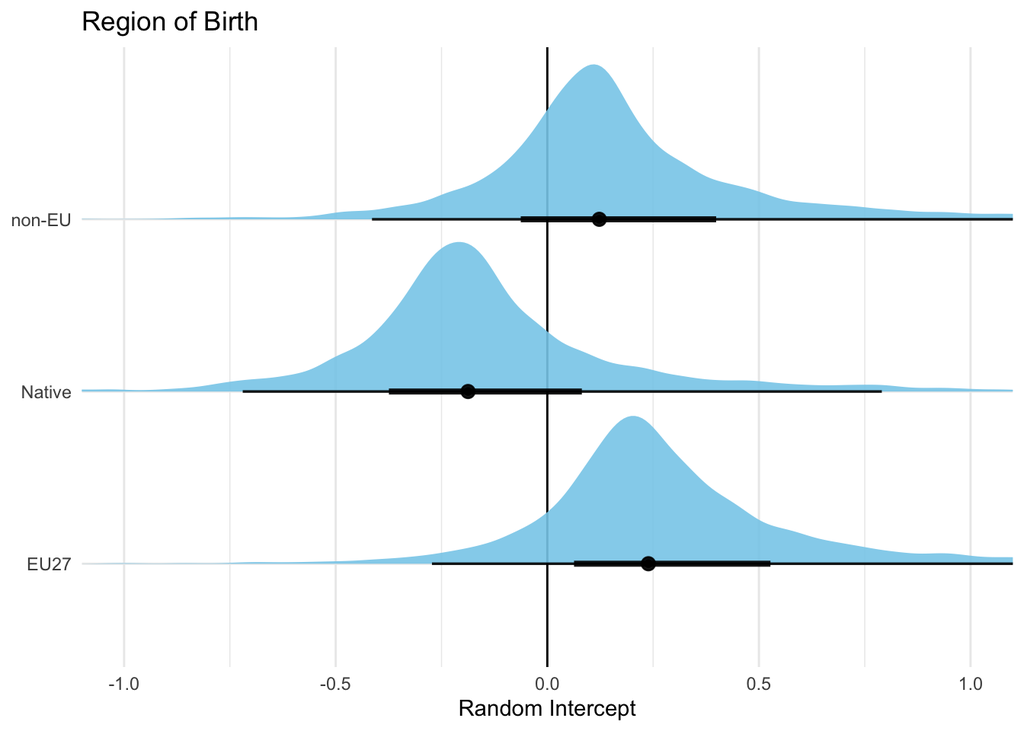

```r
m3 %>%
  spread_draws(`r_cntbrth_eu27[eu27,Intercept]`,`r_cntbrth_eu27[native,Intercept]`,`r_cntbrth_eu27[non-eu,Intercept]`) %>%
  rename(`EU27`=`r_cntbrth_eu27[eu27,Intercept]`,`Native`=`r_cntbrth_eu27[native,Intercept]`,`non-EU`=`r_cntbrth_eu27[non-eu,Intercept]`) %>%
  select(-starts_with(".")) %>%
  pivot_longer(everything()) %>%
  ggplot(aes(y = name, x = value)) +
  geom_vline(xintercept = 0) +
  stat_halfeye(fill = "skyblue", alpha = .9) +
  coord_cartesian(xlim = c(-1, 1)) +
  theme_minimal() +
  labs(y = NULL, x = "Random Intercept", title = "Region of Birth")
```

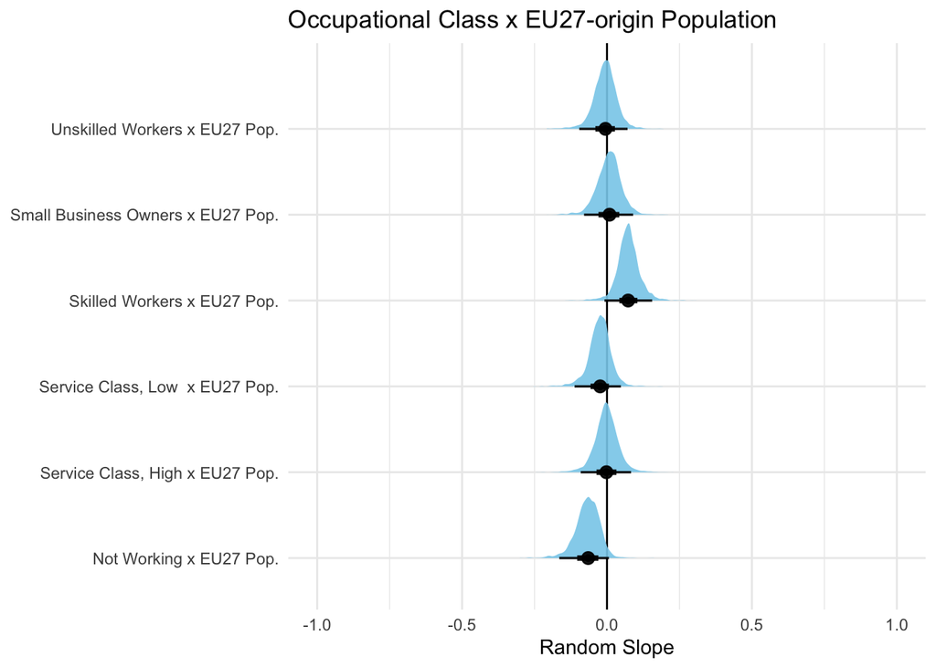

```r
m4 %>%
  spread_draws(`r_class5[1,scalepct_eu_only]`,`r_class5[2,scalepct_eu_only]`,`r_class5[3,scalepct_eu_only]`,`r_class5[4,scalepct_eu_only]`,`r_class5[5,scalepct_eu_only]`,`r_class5[not.working,scalepct_eu_only]`) %>%
  rename(`Service Class, High x EU27 Pop.`=`r_class5[1,scalepct_eu_only]`,`Service Class, Low  x EU27 Pop.`=`r_class5[2,scalepct_eu_only]`,`Small Business Owners x EU27 Pop.`=`r_class5[3,scalepct_eu_only]`,`Skilled Workers x EU27 Pop.`=`r_class5[4,scalepct_eu_only]`,`Unskilled Workers x EU27 Pop.`=`r_class5[5,scalepct_eu_only]`,`Not Working x EU27 Pop.`=`r_class5[not.working,scalepct_eu_only]`) %>%
  select(-starts_with(".")) %>%
  pivot_longer(everything()) %>%
  ggplot(aes(y = name, x = value)) +
  geom_vline(xintercept = 0) +
  stat_halfeye(fill = "skyblue", alpha = .9) +
  coord_cartesian(xlim = c(-1, 1)) +
  theme_minimal() +
  labs(y = NULL, x = "Random Slope", title = "Occupational Class x EU27-origin Population")
```

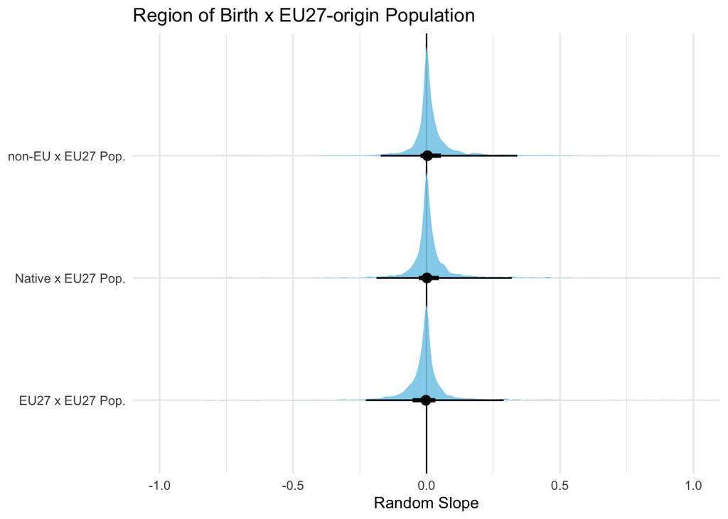

```r
m5 %>%
  spread_draws(`r_cntbrth_eu27[eu27,scalepct_eu_only]`,`r_cntbrth_eu27[native,scalepct_eu_only]`,`r_cntbrth_eu27[non-eu,scalepct_eu_only]`) %>%
  rename(`EU27 x EU27 Pop.`=`r_cntbrth_eu27[eu27,scalepct_eu_only]`,`Native x EU27 Pop.`=`r_cntbrth_eu27[native,scalepct_eu_only]`,`non-EU x EU27 Pop.`=`r_cntbrth_eu27[non-eu,scalepct_eu_only]`) %>%
  select(-starts_with(".")) %>%
  pivot_longer(everything()) %>%
  ggplot(aes(y = name, x = value)) +
  geom_vline(xintercept = 0) +
  stat_halfeye(fill = "skyblue", alpha = .9) +
  coord_cartesian(xlim = c(-1, 1)) +
  theme_minimal() +
  labs(y = NULL, x = "Random Slope", title = "Region of Birth x EU27-origin Population")
```

## Other Ideas

We talked about a few other things that I haven’t incorporated yet:

- Left-right scale as IV/interaction (I could add this in here, I just haven’t yet)
- Support for euroskeptic parties as DV
- Other attitudes (toward migrants, toward EU parliament, etc) as DV